# Tarea 6: comparacion de modelos

### Modelo 2

```r
# STD RESIDUALS
precios <- precios %>%
  mutate(std_resid2 = standardize(as.numeric(precios$olsresid2)))

summary(precios$std_resid2)
```

```
##     Min.  1st Qu.   Median     Mean  3rd Qu.     Max.
## -3.63246 -0.51333 -0.06599  0.00000  0.62833  3.67351
```

```r
tm_shape(zonas17_concepcion) +
  tm_polygons('#f0f0f0f0', border.alpha = 0.2) +
  tm_shape(precios) +
  tm_dots("std_resid2", size=0.1)
```

```
## Variable(s) "std_resid2" contains positive and negative values, so midpoint is set to 0. Set midpoint = NA to show the full spectrum of the color palette.
```

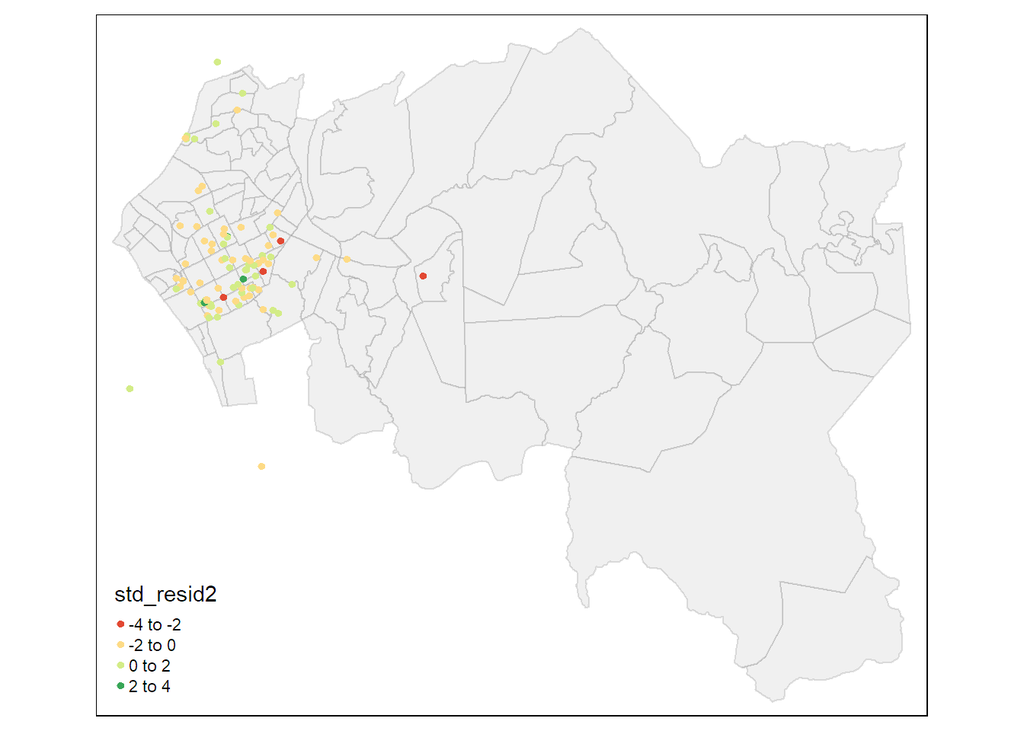

### Modelo 3

```r
# STD RESIDUALS
precios <- precios %>%
  mutate(std_resid3 = standardize(as.numeric(olsresid3)))
summary(precios$std_resid3)
```

```
##     Min.  1st Qu.   Median     Mean  3rd Qu.     Max.
## -3.60763 -0.57583 -0.04869  0.00000  0.59446  3.70558
```

```r
##    Min. 1st Qu.  Median    Mean 3rd Qu.    Max.
##   -4.62   -0.60    0.06    0.00    0.65    4.25
tm_shape(zonas17_concepcion) +
  tm_polygons('#f0f0f0f0', border.alpha = 0.2) +
  tm_shape(precios) +
  tm_dots("std_resid3", size=0.1)
```

```
## Variable(s) "std_resid3" contains positive and negative values, so midpoint is set to 0. Set midpoint = NA to show the full spectrum of the color palette.
```

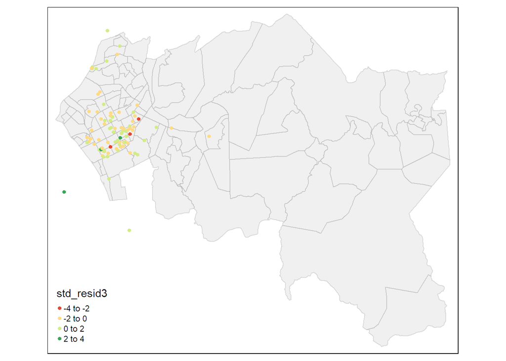

# MODELOS HEDONICOS SAR Y SEM

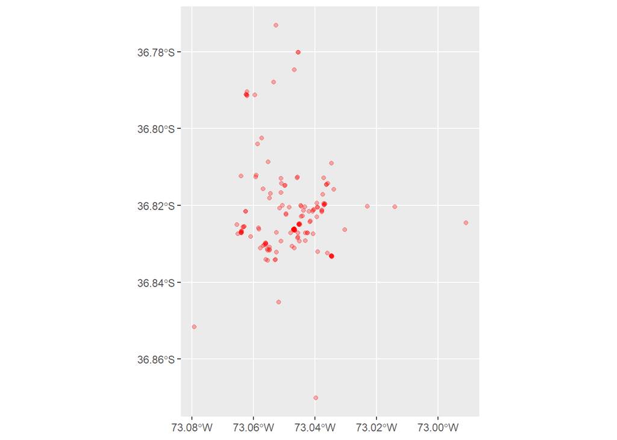

```r
nvec <- 12

# puntos identicos: jitter los "desordena"
precios_esp <- precios %>%
  st_as_sf() %>%
  st_jitter() %>%
  as_Spatial()

ggplot() +
  geom_sf() +
  geom_sf(data = st_as_sf(precios_esp), color = alpha("red",.3))
```

### Moran Test

```r
nb <- nb2listw(neighbours = knn2nb(
  knn = knearneigh(x = precios_esp, k = nvec, longlat = F)),
  style = "W")


moran.test(precios_esp$ln_uf, listw = nb)
```

```
##
##  Moran I test under randomisation
##
## data:  precios_esp$ln_uf
## weights: nb
##
## Moran I statistic standard deviate = 0.29568, p-value = 0.3837
## alternative hypothesis: greater
## sample estimates:
## Moran I statistic       Expectation          Variance
##      0.0017283525     -0.0068965517      0.0008508739
```

```r
moran.test(precios_esp$olsresid, listw = nb)
```

```
##
##  Moran I test under randomisation
##
## data:  precios_esp$olsresid
## weights: nb
##
## Moran I statistic standard deviate = 3.3639, p-value = 0.0003842
## alternative hypothesis: greater
## sample estimates:
## Moran I statistic       Expectation          Variance
##      0.0910711315     -0.0068965517      0.0008481641
```

```r
moran.test(precios_esp$olsresid2, listw = nb)
```

```
##
##  Moran I test under randomisation
##
## data:  precios_esp$olsresid2
## weights: nb
##
## Moran I statistic standard deviate = 3.4833, p-value = 0.0002477
## alternative hypothesis: greater
## sample estimates:
## Moran I statistic       Expectation          Variance
##      0.0944151257     -0.0068965517      0.0008459431
```

```r
moran.test(precios_esp$olsresid3, listw = nb)
```

```
##
##  Moran I test under randomisation
##
## data:  precios_esp$olsresid3
## weights: nb
##
## Moran I statistic standard deviate = 4.0684, p-value = 0.00002367
## alternative hypothesis: greater
## sample estimates:
## Moran I statistic       Expectation          Variance
##      0.1114538586     -0.0068965517      0.0008462479
```

```r
lm.morantest(m1, nb, alternative = "greater")
```

```
##
##  Global Moran I for regression residuals
##
## data:
## model: lm(formula = f1, data = precios)
## weights: nb
##
## Moran I statistic standard deviate = 4.2383, p-value = 0.00001126
## alternative hypothesis: greater
## sample estimates:
## Observed Moran I      Expectation         Variance
##      0.091071132     -0.020139434      0.000688505
```

```r
lm.morantest(m2, nb, alternative = "greater")
```

```
##
##  Global Moran I for regression residuals
##
## data:
## model: lm(formula = f2, data = precios)
## weights: nb
##
## Moran I statistic standard deviate = 3.8814, p-value = 0.00005192
## alternative hypothesis: greater
## sample estimates:
## Observed Moran I      Expectation         Variance
##     0.0944151257    -0.0128147582     0.0007632144
```

```r
lm.morantest(m3, nb, alternative = "greater")
```

```
##
##  Global Moran I for regression residuals
##
## data:
## model: lm(formula = f3, data = precios)
## weights: nb
##
## Moran I statistic standard deviate = 4.2018, p-value = 0.00001324
## alternative hypothesis: greater
## sample estimates:
## Observed Moran I      Expectation         Variance
##     0.1114538586    -0.0090550860     0.0008225465
```

```r
Dx <- lm.LMtests(m1, nb, test = "all")
Dx2 <- lm.LMtests(m2, nb, test = "all")
Dx3 <- lm.LMtests(m3, nb, test = "all")

summary(Dx)
```

```
##  Lagrange multiplier diagnostics for spatial dependence
## data:
## model: lm(formula = f1, data = precios)
## weights: nb
##
##        statistic parameter   p.value
## LMerr     8.6066         1 0.0033495 **
## LMlag     1.5996         1 0.2059647
## RLMerr   14.5127         1 0.0001392 ***
## RLMlag    7.5056         1 0.0061506 **
## SARMA    16.1122         2 0.0003172 ***
## ---
## Signif. codes:  0 '***' 0.001 '**' 0.01 '*' 0.05 '.' 0.1 ' ' 1
```

```r
summary(Dx2)
```

```
##  Lagrange multiplier diagnostics for spatial dependence
## data:
## model: lm(formula = f2, data = precios)
## weights: nb
##
##        statistic parameter    p.value
## LMerr     9.2502         1  0.0023546 **
## LMlag     1.5385         1  0.2148376
## RLMerr   16.8756         1 0.00003991 ***
## RLMlag    9.1639         1  0.0024684 **
## SARMA    18.4142         2  0.0001003 ***
## ---
## Signif. codes:  0 '***' 0.001 '**' 0.01 '*' 0.05 '.' 0.1 ' ' 1
```

```r
summary(Dx3)
```

```
##  Lagrange multiplier diagnostics for spatial dependence
## data:
## model: lm(formula = f3, data = precios)
## weights: nb
##
##        statistic parameter      p.value
## LMerr    12.8902         1    0.0003303 ***
## LMlag     1.9299         1    0.1647654
## RLMerr   25.0258         1 0.0000005657 ***
## RLMlag   14.0655         1    0.0001766 ***
## SARMA    26.9557         2 0.0000014017 ***
## ---
## Signif. codes:  0 '***' 0.001 '**' 0.01 '*' 0.05 '.' 0.1 ' ' 1
```

```r
mod_sim <-
  sacsarlm(
    formula = formula(f1),
    listw = nb,
    data = precios_esp
  )

mod_sim2 <-
  sacsarlm(
    formula = formula(f2),
    listw = nb,
    data = precios_esp
  )

mod_sim3 <-
  sacsarlm(
    formula = formula(f3),
    listw = nb,
    data = precios_esp
  )
```

```r
summary(mod_sim)
```

```
##
## Call:sacsarlm(formula = formula(f1), data = precios_esp, listw = nb)
##
## Residuals:
##       Min        1Q    Median        3Q       Max
## -0.475835 -0.077766 -0.017217  0.079432  0.554054
##
## Type: sac
## Coefficients: (asymptotic standard errors)
##                 Estimate   Std. Error z value    Pr(>|z|)
## (Intercept)  3.238468404  0.969558684  3.3401   0.0008373
## area_util    0.006307774  0.001391477  4.5332 0.000005811
## bathrooms2   0.004457668  0.041979753  0.1062   0.9154347
## bathrooms3   0.057247829  0.109623433  0.5222   0.6015154
## bedrooms2    0.123059969  0.046350104  2.6550   0.0079306
## bedrooms3    0.176260675  0.070329784  2.5062   0.0122036
## parque       0.000052213  0.000067489  0.7736   0.4391420
## superm       0.000054880  0.000053364  1.0284   0.3037533
## c_salud      0.000011195  0.000054757  0.2044   0.8380041
## univ        -0.000052199  0.000048102 -1.0852   0.2778453
##
## Rho: -0.47092
## Asymptotic standard error: 0.38192
##     z-value: -1.233, p-value: 0.21756
## Lambda: 0.72746
## Asymptotic standard error: 0.12005
##     z-value: 6.0596, p-value: 0.0000000013648
##
## LR test value: 12.184, p-value: 0.0022605
##
## Log likelihood: 57.35954 for sac model
## ML residual variance (sigma squared): 0.025031, (sigma: 0.15821)
## Number of observations: 146
## Number of parameters estimated: 13
## AIC: -88.719, (AIC for lm: -80.535)
```

```r
summary(mod_sim2)
```

```
##
## Call:sacsarlm(formula = formula(f2), data = precios_esp, listw = nb)
##
## Residuals:
##       Min        1Q    Median        3Q       Max
## -0.515825 -0.073913 -0.017537  0.093639  0.563454
##
## Type: sac
## Coefficients: (asymptotic standard errors)
##                  Estimate    Std. Error z value    Pr(>|z|)
## (Intercept)  3.0946662745  0.9652478615  3.2061    0.001346
## area_util    0.0065181645  0.0013995989  4.6572 0.000003206
## bathrooms2   0.0048074242  0.0422945384  0.1137    0.909503
## bathrooms3   0.0612809178  0.1094773079  0.5598    0.575644
## bedrooms2    0.1124121207  0.0456803558  2.4608    0.013861
## bedrooms3    0.1628379632  0.0693107988  2.3494    0.018804
## superm       0.0000672704  0.0000525952  1.2790    0.200890
## univ        -0.0000091851  0.0000313678 -0.2928    0.769661
##
## Rho: -0.40627
## Asymptotic standard error: 0.38072
##     z-value: -1.0671, p-value: 0.28593
## Lambda: 0.70691
## Asymptotic standard error: 0.13109
##     z-value: 5.3925, p-value: 0.000000069498
##
## LR test value: 12.458, p-value: 0.0019716
##
## Log likelihood: 56.68187 for sac model
## ML residual variance (sigma squared): 0.025439, (sigma: 0.15949)
## Number of observations: 146
## Number of parameters estimated: 11
## AIC: -91.364, (AIC for lm: -82.906)
```

```r
summary(mod_sim3)
```

```
##
## Call:sacsarlm(formula = formula(f3), data = precios_esp, listw = nb)
##
## Residuals:
##       Min        1Q    Median        3Q       Max
## -0.548003 -0.083369 -0.015180  0.094163  0.570434
##
## Type: sac
## Coefficients: (asymptotic standard errors)
##              Estimate Std. Error z value    Pr(>|z|)
## (Intercept) 3.2552511  0.9854333  3.3034   0.0009553
## area_util   0.0066771  0.0014021  4.7623 0.000001914
## bathrooms2  0.0073669  0.0422788  0.1742   0.8616719
## bathrooms3  0.0550991  0.1090640  0.5052   0.6134182
## bedrooms2   0.1005826  0.0454714  2.2120   0.0269670
## bedrooms3   0.1480976  0.0693198  2.1364   0.0326435
##
## Rho: -0.46095
## Asymptotic standard error: 0.3887
##     z-value: -1.1859, p-value: 0.23566
## Lambda: 0.68929
## Asymptotic standard error: 0.13773
##     z-value: 5.0045, p-value: 0.00000056017
##
## LR test value: 13.005, p-value: 0.0014995
##
## Log likelihood: 55.754 for sac model
## ML residual variance (sigma squared): 0.025799, (sigma: 0.16062)
## Number of observations: 146
## Number of parameters estimated: 9
## AIC: -93.508, (AIC for lm: -84.503)
```

# MODELOS HEDONICOS GWR

```r
precios_latlon <- precios %>%
  dplyr::mutate(x = sf::st_coordinates(.)[,1],
                y = sf::st_coordinates(.)[,2]) %>%
  sf::st_set_geometry(NULL)

GWRbandwidth <- gwr.sel(f1, data = precios_latlon, coords = cbind(precios_latlon$x, precios_latlon$y),adapt=T)
```

```
## Adaptive q: 0.381966 CV score: 5.168865
## Adaptive q: 0.618034 CV score: 5.199926
## Adaptive q: 0.236068 CV score: 5.219258
## Adaptive q: 0.4473167 CV score: 5.16494
## Adaptive q: 0.4413918 CV score: 5.170035
## Adaptive q: 0.5125249 CV score: 5.172837
## Adaptive q: 0.472224 CV score: 5.181579
## Adaptive q: 0.4568305 CV score: 5.171642
## Adaptive q: 0.4509506 CV score: 5.167431
## Adaptive q: 0.4450536 CV score: 5.163701
## Adaptive q: 0.4436549 CV score: 5.166028
## Adaptive q: 0.4457318 CV score: 5.163828
## Adaptive q: 0.4449825 CV score: 5.163817
## Adaptive q: 0.4453541 CV score: 5.16356
## Adaptive q: 0.4454984 CV score: 5.163663
## Adaptive q: 0.4452923 CV score: 5.163517
## Adaptive q: 0.4452011 CV score: 5.163462
## Adaptive q: 0.4451448 CV score: 5.163553
## Adaptive q: 0.4452418 CV score: 5.163481
## Adaptive q: 0.4452011 CV score: 5.163462
```

```r
gwr.model = gwr(f1, data = precios_latlon, coords = cbind(precios_latlon$x, precios_latlon$y), adapt = GWRbandwidth, hatmatrix = TRUE, se.fit = TRUE)

gwr.model
```

```
## Call:
## gwr(formula = f1, data = precios_latlon, coords = cbind(precios_latlon$x,
##     precios_latlon$y), adapt = GWRbandwidth, hatmatrix = TRUE,
##     se.fit = TRUE)
## Kernel function: gwr.Gauss
## Adaptive quantile: 0.4452011 (about 64 of 146 data points)
## Summary of GWR coefficient estimates at data points:
##                       Min.       1st Qu.        Median       3rd Qu.
## X.Intercept.  1.9920932516  2.0280974742  2.0437216693  2.0530875099
## area_util     0.0035132691  0.0047520738  0.0054802551  0.0065938975
## bathrooms2   -0.0389155305 -0.0248981238 -0.0097993500  0.0020203869
## bathrooms3    0.0311975620  0.0928063046  0.1223845921  0.1503121386
## bedrooms2     0.0713979778  0.0960672665  0.1167918117  0.1351928302
## bedrooms3     0.0923567337  0.1287767543  0.1566249235  0.1843153972
## parque        0.0000697715  0.0000972817  0.0001133091  0.0001363369
## superm       -0.0001349683 -0.0000548228 -0.0000359704 -0.0000014766
## c_salud      -0.0001355253 -0.0000878572 -0.0000652868 -0.0000467917
## univ          0.0000049582  0.0000951887  0.0001107843  0.0001177824
##                       Max. Global
## X.Intercept.  2.1324486673 2.0549
## area_util     0.0074280915 0.0071
## bathrooms2    0.0250868651 0.0097
## bathrooms3    0.1765735416 0.0378
## bedrooms2     0.1461261978 0.0661
## bedrooms3     0.2430717862 0.1022
## parque        0.0001973440 0.0001
## superm        0.0000735972 0.0000
## c_salud      -0.0000119623 0.0000
## univ          0.0001547311 0.0000
## Number of data points: 146
## Effective number of parameters (residual: 2traceS - traceS'S): 23.33958
## Effective degrees of freedom (residual: 2traceS - traceS'S): 122.6604
## Sigma (residual: 2traceS - traceS'S): 0.1673683
## Effective number of parameters (model: traceS): 18.78004
## Effective degrees of freedom (model: traceS): 127.22
## Sigma (model: traceS): 0.1643417
## Sigma (ML): 0.1534083
## AICc (GWR p. 61, eq 2.33; p. 96, eq. 4.21): -86.94337
## AIC (GWR p. 96, eq. 4.22): -114.2883
## Residual sum of squares: 3.43598
## Quasi-global R2: 0.5421091
```

# COMPARACION Y PRESENTACION DE RESULTADOS

```r
results_gwr <- gwr.model$SDF@data$pred
results_sar <- mod_sim$fitted.values
results_ols <- m1$fitted.values

precios_results <- precios %>%
  cbind(results_gwr) %>%
  cbind(results_sar) %>%
  cbind(results_ols) %>%
  mutate(
    pred_GWR = exp(results_gwr),
    pred_SAR = exp(results_sar),
    pred_OLS = exp(results_ols)
  )
```

```r
MSE_OLS <- mean((precios_results$results_ols-precios_results$ln_uf)^2)#Calculo del promedio de los errores cuadradas por el modelo 2
MSE_GWR <- mean((precios_results$results_gwr-precios_results$ln_uf)^2)#Calculo del promedio de los errores cuadradas por el modelo 2
MSE_SAR <- mean((precios_results$results_sar-precios_results$ln_uf)^2)#Calculo del promedio de los errores cuadradas por el modelo 2

MSE_OLS
```

```
## [1] 0.0290084
```

```r
MSE_GWR
```

```
## [1] 0.02353411
```

```r
MSE_SAR
```

```
## [1] 0.02503079
```

El modelo menos explicativo corresponde al OLS debido a que es el que posee mayor error cuadratico medio. En relación a los modelos restantes, el mejor corresponde al GWR. Cabe destacar que a pesar de esto, los errores cuadraticos medios entre los modelos son similares.

```r
AIC_OLS <- AIC(m2)
AIC_SAR <- AIC(mod_sim)
AIC_GWR <- gwr.model$results$AICh
```

```r
AIC_OLS
```

```
## [1] -82.90589
```

```r
AIC_GWR
```

```
## [1] -114.2883
```

```r
AIC_SAR
```

```
## [1] -88.71909
```

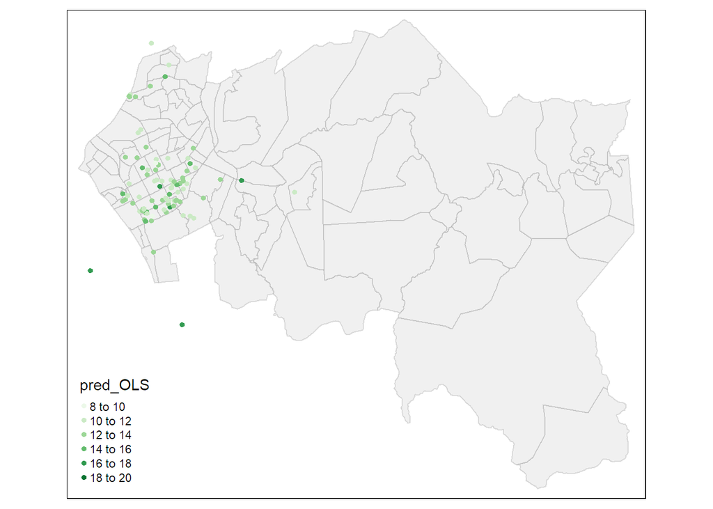

```r
tm_shape(zonas17_concepcion) +
  tm_polygons('#f0f0f0f0', border.alpha = 0.2) +
  tm_shape(precios_results) +
  tm_dots("pred_OLS", size = 0.1, palette = 'Greens')
```

En este caso, el modelo GWR es el que presenta un mejor valor (menor) que los dos modelos restantes, corroborando la hipotesis de que es el mejor modelo con el menor MSE. Es por esto que podemos concluir que es el modelo que entrega mayor información respecto al caso de estudio.

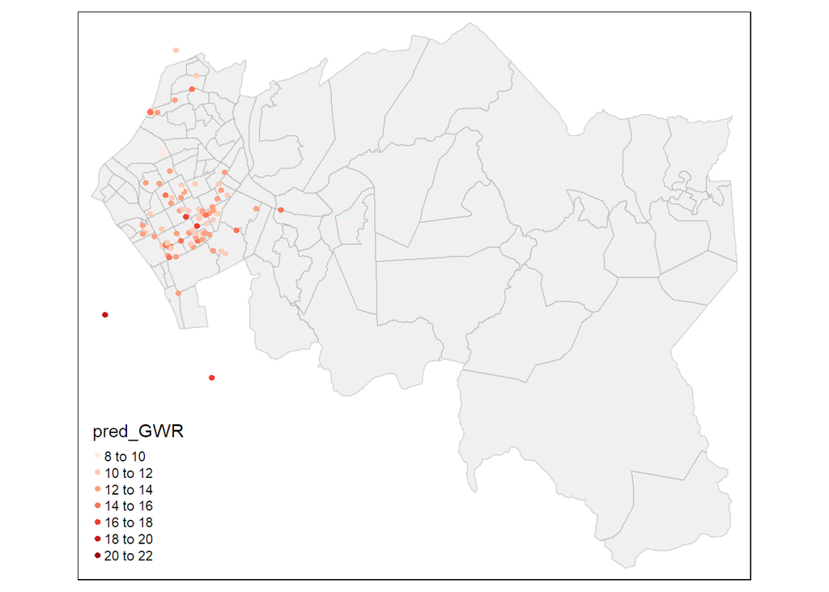

```r
tm_shape(zonas17_concepcion) +
  tm_polygons('#f0f0f0f0', border.alpha = 0.2) +
  tm_shape(precios_results) +
  tm_dots("pred_GWR", size = 0.1, palette = 'Reds')
```

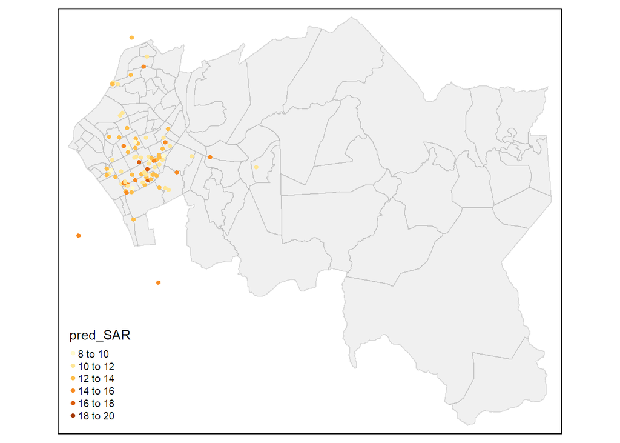

```r
tm_shape(zonas17_concepcion) +
  tm_polygons('#f0f0f0f0', border.alpha = 0.2) +
  tm_shape(precios_results) +
  tm_dots("pred_SAR", size=0.1)
```

```r
ae_plot_sp_utm <- zonas17_concepcion %>%
  st_transform(crs_utm) %>%
  as_Spatial()

Precios_sp_utm <- precios_results %>%
  st_transform(crs_utm) %>%
  as_Spatial()


ext <- raster::extent(Precios_sp_utm)
x_min <- ext[1] - 100
x_max <- ext[2] + 100
y_min <- ext[3] - 100
y_max <- ext[4] + 100


grd <- expand.grid(x = seq(from = x_min, to = x_max, by = 100),
                   y = seq(from = y_min, to = y_max, by = 100))
coordinates(grd) <- ~x + y
gridded(grd) <- TRUE
proj4string(grd) <- crs_utm

idw_precios_gwr <-
  gstat::idw(
    formula = Precios_sp_utm@data$pred_GWR ~ 1, # variable a interpolar
    locations = Precios_sp_utm, # informacion geografica
    newdata = grd, # grilla donde será interpolado nuestra variable
    idp = 1,
    na.action = na.omit,
    nmax = 4
  )
```

```
## [inverse distance weighted interpolation]
```

```r
idw_precios_UF <-
  gstat::idw(
    formula = Precios_sp_utm@data$uf ~ 1, # variable a interpolar
    locations = Precios_sp_utm, # informacion geografica
    newdata = grd, # grilla donde será interpolado nuestra variable
    idp = 1,
    na.action = na.omit,
    nmax = 4
  )
```

```
## [inverse distance weighted interpolation]
```

```r
idw_precios_OLS <-
  gstat::idw(
    formula = Precios_sp_utm@data$pred_OLS ~ 1, # variable a interpolar
    locations = Precios_sp_utm, # informacion geografica
    newdata = grd, # grilla donde será interpolado nuestra variable
    idp = 1,
    na.action = na.omit,
    nmax = 4
  )
```

```
## [inverse distance weighted interpolation]
```

```r
idw_precios_SAR <-
  gstat::idw(
    formula = Precios_sp_utm@data$pred_SAR ~ 1, # variable a interpolar
    locations = Precios_sp_utm, # informacion geografica
    newdata = grd, # grilla donde será interpolado nuestra variable
    idp = 1,
    na.action = na.omit,
    nmax = 4
  )
```

```
## [inverse distance weighted interpolation]
```

```r
proj4string(idw_precios_gwr) <- proj4string(Precios_sp_utm)
proj4string(idw_precios_SAR) <- proj4string(Precios_sp_utm)
proj4string(idw_precios_OLS) <- proj4string(Precios_sp_utm)
proj4string(idw_precios_UF) <- proj4string(Precios_sp_utm)

# acotamos datos a area de estudio
idw_precios_gwr <- mask(raster(idw_precios_gwr), ae_plot_sp_utm)
idw_precios_SAR <- mask(raster(idw_precios_SAR), ae_plot_sp_utm)
idw_precios_OLS <- mask(raster(idw_precios_OLS), ae_plot_sp_utm)
idw_precios_UF <- mask(raster(idw_precios_UF), ae_plot_sp_utm)
```

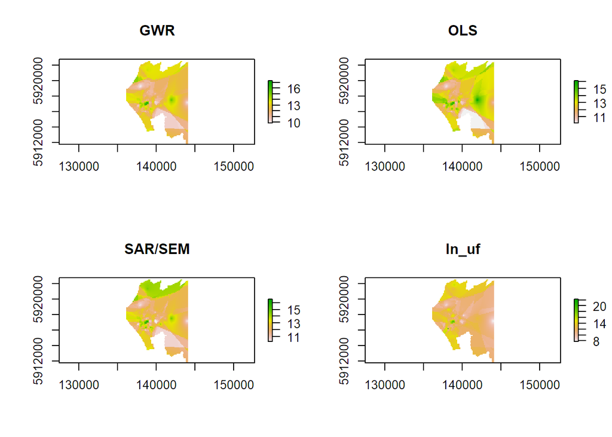

```r
par(mfrow = c(2,2)) #Permite graficar más de una imagen por pantalla

plot(idw_precios_gwr)
title(main = "GWR")

plot(idw_precios_OLS)
title(main = "OLS")

plot(idw_precios_SAR)
title(main = "SAR/SEM")

plot(idw_precios_UF)
title(main = "ln_uf")
```

```r
par(mfrow = c(1,1)) #Permite graficar más de una imagen por pantalla

idw_3D <- as.matrix(idw_precios_SAR)

persp3d(idw_3D, col = "lightblue")
```

```r
GWR_Color <- colorNumeric(palette = brewer.pal(10, name = 'Purples'), values(idw_precios_gwr), na.color = "transparent")
OLS_Color <- colorNumeric(palette = brewer.pal(10, name = "Reds"), values(idw_precios_OLS), na.color = "transparent")
SAR_Color<- colorNumeric(palette = brewer.pal(10, name = "Blues"), values(idw_precios_SAR), na.color = "transparent")
UF_Color <- colorNumeric(palette = brewer.pal(10, name = "Oranges"), values(idw_precios_UF), na.color = "transparent")


leaflet(ae_plot_sp_utm)%>%
  addTiles(group="OSM defautlt")%>%
  addProviderTiles(providers$Stamen.TonerLite, group = "Toner Lite")%>%
  addProviderTiles(providers$Esri.WorldImagery, group = "Satellite")%>%
  addRasterImage(idw_precios_gwr,opacity = 0.8,colors = GWR_Color,group="GWR")%>%
  addLegend("bottomright", pal = GWR_Color, values = values(idw_precios_gwr), group = "GWR",
          title = "GWR", opacity = 0.3)%>%
  addRasterImage(idw_precios_OLS,opacity = 0.8,colors = OLS_Color,group="OLS")%>%
   addLegend("bottomleft", pal = OLS_Color, values = values(idw_precios_OLS), group = "OLS",
          title = "OLS", opacity = 0.4)%>%
  addRasterImage(idw_precios_SAR,opacity = 0.8,colors = SAR_Color,group="SAR")%>%
   addLegend("bottomleft", pal = SAR_Color, values = values(idw_precios_SAR), group = "SAR",
          title = "SAR", opacity = 0.4)%>%
  addRasterImage(idw_precios_UF,opacity = 0.8,colors = UF_Color,group="UF")%>%
   addLegend("bottomright", pal = UF_Color, values = values(idw_precios_UF), group = "UF",
          title = "UF", opacity = 0.4)%>%
  addLayersControl(
    baseGroups = c("OSM", "Toner Lite", "Satellite"),
    overlayGroups = c("GWR", "OLS", "SAR", "UF"),
    options = layersControlOptions(collapsed = TRUE)
  )
```

[interactive chart not shown]

```r
precios$bedrooms <- as.numeric(precios$bedrooms)
precios$bathrooms <- as.numeric(precios$bathrooms)
summary(precios)
```

```
##      precio          bedrooms       bathrooms       area_total
##  Min.   :200000   Min.   :1.000   Min.   :1.000   Min.   : 17.00
##  1st Qu.:320000   1st Qu.:1.000   1st Qu.:1.000   1st Qu.: 39.00
##  Median :350000   Median :2.000   Median :1.000   Median : 50.00
##  Mean   :375244   Mean   :1.685   Mean   :1.452   Mean   : 52.06
##  3rd Qu.:400000   3rd Qu.:2.000   3rd Qu.:2.000   3rd Qu.: 60.00
##  Max.   :853190   Max.   :3.000   Max.   :3.000   Max.   :111.00
##    area_util         dir                     geometry         uf
##  Min.   :17.00   Length:146         POINT        :146   Min.   : 6.723
##  1st Qu.:37.00   Class :character   epsg:4326    :  0   1st Qu.:10.756
##  Median :48.00   Mode  :character   +proj=long...:  0   Median :11.765
##  Mean   :49.55                                          Mean   :12.613
##  3rd Qu.:60.00                                          3rd Qu.:13.445
##  Max.   :94.00                                          Max.   :28.679
##       ufm2            ln_uf          area_ln          superm
##  Min.   :0.1159   Min.   :1.905   Min.   :2.833   Min.   :  19.52
##  1st Qu.:0.2213   1st Qu.:2.375   1st Qu.:3.664   1st Qu.: 146.61
##  Median :0.2512   Median :2.465   Median :3.912   Median : 243.85
##  Mean   :0.2575   Mean   :2.507   Mean   :3.898   Mean   : 354.51
##  3rd Qu.:0.2816   3rd Qu.:2.599   3rd Qu.:4.094   3rd Qu.: 382.09
##  Max.   :0.5229   Max.   :3.356   Max.   :4.710   Max.   :2471.87
##     c_salud             univ             parque          olsresid
##  Min.   :  17.66   Min.   :  88.09   Min.   : 140.6   Min.   :-0.569054
##  1st Qu.: 177.61   1st Qu.: 323.69   1st Qu.: 611.1   1st Qu.:-0.101233
##  Median : 370.34   Median : 638.56   Median : 720.3   Median :-0.007084
##  Mean   : 675.41   Mean   : 712.10   Mean   : 885.5   Mean   : 0.000000
##  3rd Qu.: 692.39   3rd Qu.: 942.46   3rd Qu.: 919.5   3rd Qu.: 0.101697
##  Max.   :4312.39   Max.   :4537.88   Max.   :4035.8   Max.   : 0.613173
##    olsresid2          olsresid3           std_resid          std_resid2
##  Min.   :-0.62428   Min.   :-0.625135   Min.   :-3.32965   Min.   :-3.63246
##  1st Qu.:-0.08822   1st Qu.:-0.099779   1st Qu.:-0.59234   1st Qu.:-0.51333
##  Median :-0.01134   Median :-0.008437   Median :-0.04145   Median :-0.06599
##  Mean   : 0.00000   Mean   : 0.000000   Mean   : 0.00000   Mean   : 0.00000
##  3rd Qu.: 0.10798   3rd Qu.: 0.103009   3rd Qu.: 0.59505   3rd Qu.: 0.62833
##  Max.   : 0.63133   Max.   : 0.642107   Max.   : 3.58780   Max.   : 3.67351
##    std_resid3
##  Min.   :-3.60763
##  1st Qu.:-0.57583
##  Median :-0.04869
##  Mean   : 0.00000
##  3rd Qu.: 0.59446
##  Max.   : 3.70558
```

```r
# Matriz de correlaciones
precios_num <- as.data.frame(precios) %>%
  dplyr::select(c(area_util, precio, parque, c_salud, univ, bathrooms, bedrooms))

cor(precios_num)
```

```
##            area_util     precio      parque    c_salud       univ  bathrooms
## area_util 1.00000000 0.62405923  0.03218013 0.02581330 0.08734042 0.71432353
## precio    0.62405923 1.00000000  0.11605123 0.07627824 0.16302382 0.45711715
## parque    0.03218013 0.11605123  1.00000000 0.88489781 0.62061648 0.05070310
## c_salud   0.02581330 0.07627824  0.88489781 1.00000000 0.56533082 0.04673777
## univ      0.08734042 0.16302382  0.62061648 0.56533082 1.00000000 0.14894341
## bathrooms 0.71432353 0.45711715  0.05070310 0.04673777 0.14894341 1.00000000
## bedrooms  0.69364092 0.47948131 -0.04025665 0.06851360 0.05512071 0.67466772
##              bedrooms
## area_util  0.69364092
## precio     0.47948131
## parque    -0.04025665
## c_salud    0.06851360
## univ       0.05512071
## bathrooms  0.67466772
## bedrooms   1.00000000
```

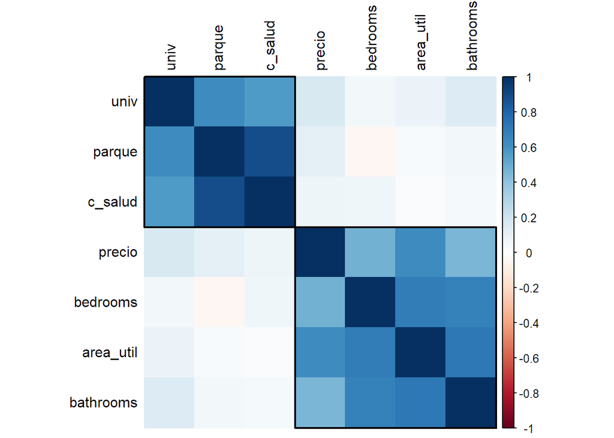

```r
library(corrplot)
M <- cor(precios_num)

corrplot(M, method = 'color', order = 'hclust', addrect = 2, tl.col = 'black')
```

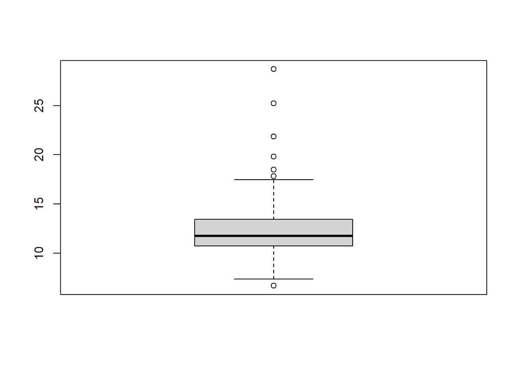

```r
boxplot(precios$uf)
```

```r
stdv_m1 <- sd(m1$residuals)
stdv_m2 <- sd(m2$residuals)
stdv_m3 <- sd(m3$residuals)

stdv_m1
```

```
## [1] 0.1709048
```

```r
stdv_m2
```

```
## [1] 0.1718608
```

```r
stdv_m3
```

```
## [1] 0.173281
```

```r
MSE_m1 <- mean((m1$residuals)^2)
MSE_m2 <- mean((m2$residuals)^2)
MSE_m3 <- mean((m3$residuals)^2)

MSE_m1
```

```
## [1] 0.0290084
```

```r
MSE_m2
```

```
## [1] 0.02933385
```

```r
MSE_m3
```

```
## [1] 0.02982066
```

```r
AIC_m1 <- AIC(m1)
AIC_m2 <- AIC(m2)
AIC_m3 <- AIC(m3)

AIC_m1
```

```
## [1] -80.53475
```

```r
AIC_m2
```

```
## [1] -82.90589
```

```r
AIC_m3
```

```
## [1] -84.50282
```